# Final Geog 490

2024-03-12

# Fires in Oregon

## Juliette Setudeh Nejad

### Bar Chart Showing Fire Cause by Acreage Burned

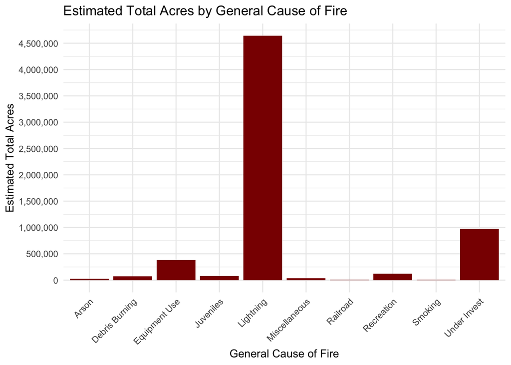

```r
ggplot(fire, aes(x = GeneralCause, y = EstTotalAcres)) +
  geom_bar(stat = "identity", fill = "darkred") +
  labs(x = "General Cause of Fire",
       y = "Estimated Total Acres",
       title = "Estimated Total Acres by General Cause of Fire") +
  theme_minimal() +
  theme(axis.text.x = element_text(angle = 45, hjust = 1))+
  scale_y_continuous(labels = scales::comma, breaks = scales::pretty_breaks(n = 10))
```

In the barchart depicting fire causes by acreage burned, it’s evident that lightning stands out as the primary contributer to fires. I wanted to learn more about how lightning was the main cause of fire throughout the years.

### Different Causes of Fire and their Cumulative Acres

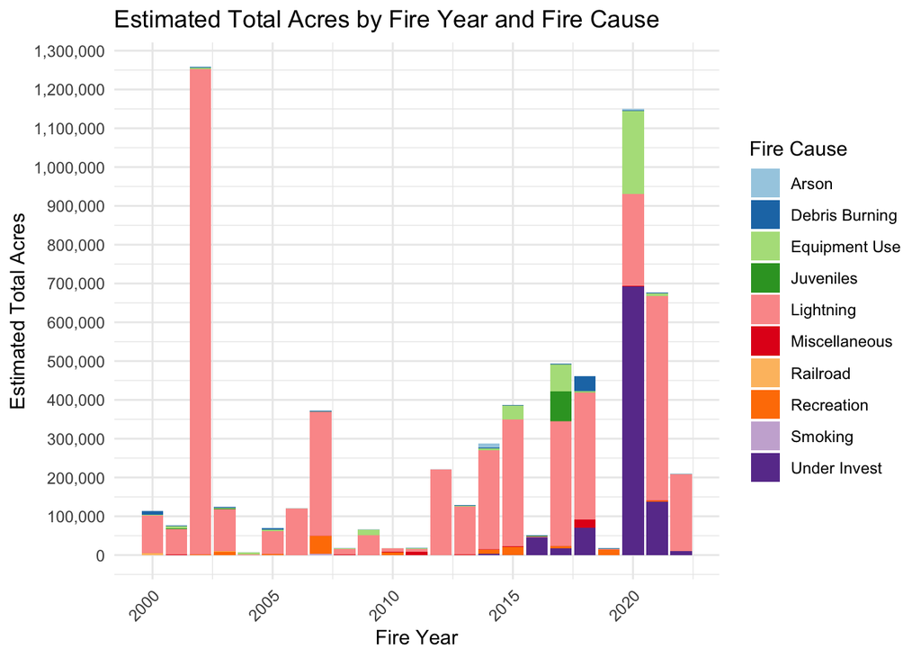

```r
palette <- brewer.pal(n = length(unique(fire$GeneralCause)), name = "Paired")

ggplot(fire, aes(x = FireYear, y = EstTotalAcres, fill = GeneralCause)) +
  geom_bar(stat = "identity") +
  labs(x = "Fire Year",
       y = "Estimated Total Acres",
       title = "Estimated Total Acres by Fire Year and Fire Cause",
       fill = "Fire Cause") +
  scale_fill_manual(values = palette) +
  theme_minimal() +
  theme(axis.text.x = element_text(angle = 45, hjust = 1)) +
  scale_y_continuous(labels = scales::comma, breaks = scales::pretty_breaks(n = 10))
```

### Top Fire Cause of Each Year with its Associated Total Acreage

```r
selected_columns <- dplyr::select(fire, FireYear, GeneralCause, EstTotalAcres)

top_cause_table <- selected_columns %>%
  group_by(FireYear) %>%
  top_n(1, EstTotalAcres) %>%
  arrange(FireYear)

print(top_cause_table)
```

```
## # A tibble: 24 × 3
## # Groups:   FireYear [23]
##    FireYear GeneralCause  EstTotalAcres
##       <int> <chr>                 <dbl>
##  1     2000 Lightning            56319
##  2     2001 Lightning            32352
##  3     2002 Lightning           499945
##  4     2002 Lightning           499945
##  5     2003 Lightning            90376
##  6     2004 Equipment Use         4705
##  7     2005 Lightning            42700
##  8     2006 Lightning            53523.
##  9     2007 Lightning           140360
## 10     2008 Lightning             4891.
## # ℹ 14 more rows
```

I wanted to create a table to give me the exact numbers of the top cause for fire throughout the years.

# Spatial Visualization using Maps

### Map of Oregon Fires from 2000-2022

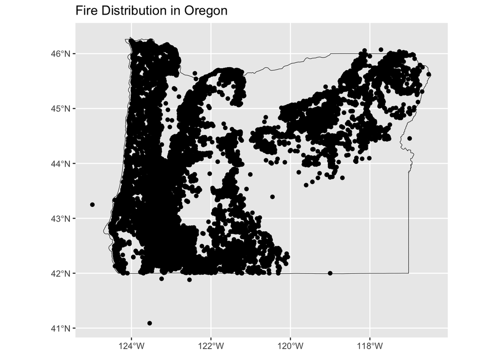

```r
ggplot() +
  geom_sf(data = fireshp, fill = "red", color = "black") +
  geom_sf(data = or_shape, fill = NA, color = "black", size = 1) +
  labs(title = "Fire Distribution in Oregon") +
  theme_grey()
```

This graph displays the total distribution of Oregon Fires from 2000-2022.

### Human vs Lightning Causation Fire Map in Oregon

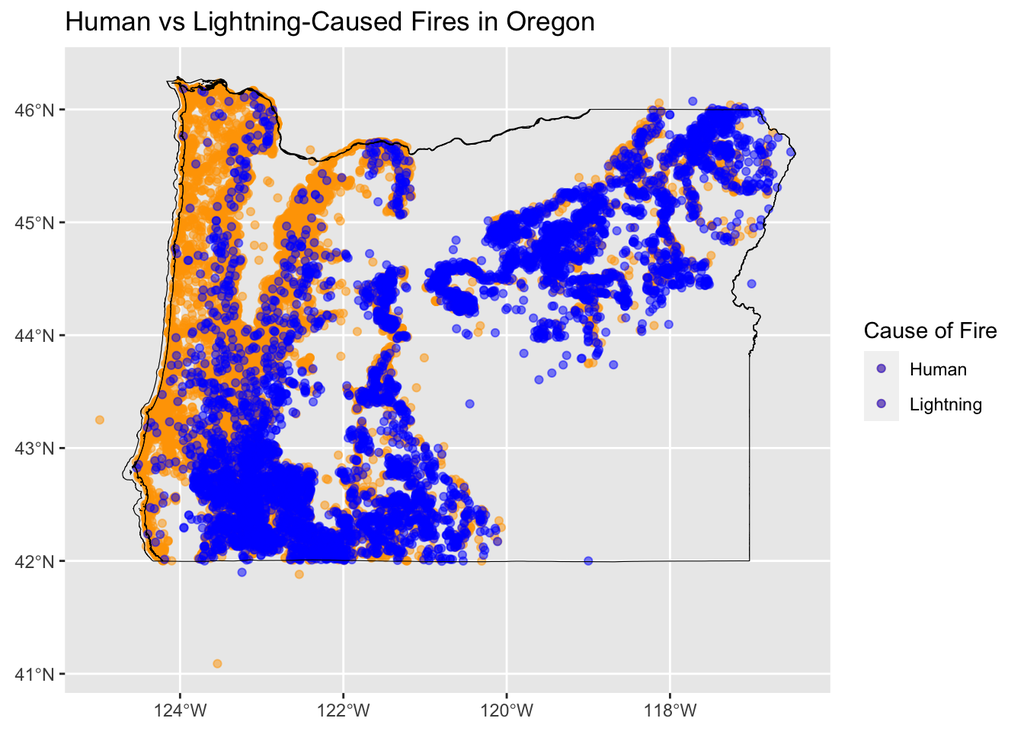

```r
lightning_fires <- fireshp[fireshp$humanorlig == "Lightning", ]

human_fires <- fireshp[fireshp$humanorlig == "Human", ]

ggplot() +
  geom_sf(data = human_fires, aes(fill = "Human"), color = "orange", alpha = 0.5) +
  geom_sf(data = lightning_fires, aes(fill = "Lightning"), color = "blue", alpha = 0.5) +
   geom_sf(data = orsf, fill = "NA", color = "black", size = 1) +
  scale_fill_manual(values = c("orange", "blue"),
                    name = "Cause of Fire",
                    labels = c("Human", "Lightning")) +
  labs(title = "Human vs Lightning-Caused Fires in Oregon") +
  theme_grey()
```

From the previous bar charts I wanted to visualize the distribution of lightning vs. human caused fires in Oregon.